# Hyperoxia & Sepsis: Preliminary Report

C. V. Cosgriff, MD/MPH Student, Harvard Chan School

## Libraries

```r
library(tidyverse)
library(stringr)
library(RPostgreSQL)
library(MIMICbook)
library(epitools)
library(tableone)
library(sjstats)
library(sjPlot)
library(broom)
library(rms)
library(quantreg)
library(pROC)
library(separationplot)
library(heatmapFit)
library(rstudioapi)
```

## Data Loading

```r
drv <- dbDriver("PostgreSQL")
mimic <- dbConnect(drv, dbname = "mimic", host = "10.8.0.1", port = 5432,
                   user = "mimicuser",
                   password = askForPassword("MIMIC Password: "))
```

## Load the Data

The dataset was generated in multiple steps; these are found cohort3.sql. Because of a computational limitation, we couldn’t pull directly from Postgres for the SpO2 items.

```r
cohort.df <- dbGetQuery(mimic,
                        "SELECT * FROM mimiciii.hyperoxia_sepsis_covariates2")

colnames.spo2 <- c("row_id", "subject_id", "hadm_id", "icustay_id",
                   "charttime", "ventstart", "ventend", "valuenum")
spo2.df <- read_csv("D:/HST953_data/hyperoxia_sepsis_spo2.csv", col_names = colnames.spo2)
```

## Cleaning the Data: Part 1

Lets screen for missing data in general.

```r
sapply(cohort.df, function(x) sum(is.na(x)))
```

```
##           subject_id              hadm_id            admittime
##                    0                    0                    0
##           icustay_id       first_careunit                  age
##                    0                    0                    0
##               gender            ethnicity   icu_length_of_stay
##                    0                    0                    0
##        vent_duration                oasis           elixhauser
##                    0                    0                    0
##     vasopressor_flag hospital_expire_flag      one_year_expire
##                    0                    0                    0
```

No missing data in the cohort.

```r
sapply(spo2.df, function(x) sum(is.na(x)))
```

```
##     row_id subject_id    hadm_id icustay_id  charttime  ventstart
##          0          0          0          0          0          0
##    ventend   valuenum
##          0         70
```

Missing 70 values out of 374578; trivial to exlcude.

```r
spo2.df <- spo2.df %>% na.omit()
```

Now lets just check if we have any nonsensical values for Spo2.

```r
spo2.df[spo2.df$valuenum > 100,]$valuenum
```

```
## [1] 1000  983
```

```r
length(spo2.df[spo2.df$valuenum > 100,]$valuenum)
```

```
## [1] 2
```

Only two out of 374508; also trivial to exclude.

What about <94? Because we excluded patients with>2 SpO2 readings below 94, we made the implict assumption that the two or less they had were recording errors. As such, these should be excluded, but lets check how much data that would be exluding.

```r
length(spo2.df[spo2.df$valuenum < 94,]$valuenum)
```

```
## [1] 2412
```

Here we have 2412 records of 374508; these were presumed errors by study design, and in this case account for a very small proportion of the data. The approach used to determine hyperoxic time won’t include them to begin with, and so they can be excluded. The very small number of them indicates that the extraction worked properly, and that they represent an exlcudable portion of our dataset.

```r
spo2.tidy.df <- spo2.df %>% filter(valuenum <= 100 & valuenum >= 94)
```

We want to also check if there any vent stretches for which only one SpO2 recording occurred; this should be rare considering we exclude anyone with <4h on the vent because we assume that there is at least one recording per hour. ##

```r
spo2.count.df <- spo2.tidy.df %>% group_by(icustay_id) %>%
  summarise(count = n()) %>% filter(count < 4)
print(spo2.count.df)
```

```
## # A tibble: 1 x 2
##   icustay_id count
##        <int> <int>
## 1     219104     1
```

There was only one ICU stay with this problem, and this was the only ICU stay for that patient, and so we’ll remove it; as it is only one observation this is unlikely to induce any bias, and it would likely be more biased to include a pateint who was on a vent for >=4 hours but had only 1 SpO2 recording.

```r
cohort.df <- cohort.df %>% filter(!(cohort.df$icustay_id %in% spo2.count.df$icustay_id))
spo2.tidy.df <- spo2.tidy.df %>% filter(!(spo2.tidy.df$icustay_id %in% spo2.count.df$icustay_id))
```

MIMIC-III codes age > 89 as ~300 to protect confientiality, and the manual says the median age for that group was 91.4. We’ll also code gender M = 1, F = 0.

```r
cohort.df[cohort.df$age > 89, "age"] <- 91.4
cohort.df$gender <- as.numeric(cohort.df$gender == "M")
```

```r
ethnicities <- c("WHITE", "BLACK", "HISPANIC", "ASIAN")

for (i in 1:length(ethnicities)) {
  cohort.df$ethnicity[str_detect(cohort.df$ethnicity, ethnicities[i])] <- ethnicities[i]
}
cohort.df$ethnicity[!(cohort.df$ethnicity %in% ethnicities)] <- "OTHER"
```

Before we cleanup the data further, we need to get a tidy data frame, and so we need to take all of SpO2 data, calculate hyperoxic times, and then join this information to our cohort table.

## Hyperoxic Durations

### Duration of Exposure

The following function was developed to calculate the amount of time hyperoxic. Intervals are calculated from chart times, and SpO2 values are considered constant between each interval.

```r
hyperoxicTime <- function(times, value) {
  icustay.spO2 <- data.frame(time = times, value = value)
  icustay.spO2 <- icustay.spO2[order(icustay.spO2$time),]
  intervals <- as.numeric(icustay.spO2$time - lag(icustay.spO2$time))
  intervals <- lead(intervals)
  intervals[is.na(intervals)] <- 0

  # Intervals are usually ~60, we will tolerate as many as three missed entries
  # or other errors; beyond that the result will be tossed.
  intervals[intervals >= 3*60] <- 0

  icustay.spO2 <- icustay.spO2 %>% mutate(duration = intervals)
  o2levels <- icustay.spO2 %>% group_by(value) %>%
    summarise(time_at = as.numeric(sum(duration))) %>% arrange(desc(value))
  o2levels[is.na(o2levels)] <- 0
  colnames(o2levels)[1] <- "satValue"
  dur.100 <- as.numeric(o2levels[o2levels$satValue == 100, 2])
  dur.99 <-  as.numeric(o2levels[o2levels$satValue == 99, 2])

  # Because some patients will never have any values at 99 or 100, we need to
  # return a 0 for these times; however they will be null. We need to clean
  # this up.
  if (is.null(dur.100) | length(dur.100) <= 0) {
    dur.100 <- 0
  }
    if (is.null(dur.99) | length(dur.99) <= 0) {
    dur.99 <- 0
  }
  if (is.na(dur.100)) {
    dur.100 <- 0
  }
  if (is.na(dur.99)) {
    dur.99 <- 0
  }

  # Now we can calculate the hyperoxic time and return it
  hyperoxic.time <- (dur.100 + dur.99) / 60
  return(hyperoxic.time)
}
```

With this function, durations of hyperoxia (>98%) were calcualted for each ICU stay ID.

```r
spo2.profiled <- spo2.tidy.df %>%
  group_by(icustay_id) %>% summarise(hyperoxic_dur = as.numeric(hyperoxicTime(charttime, valuenum)))
```

Now we can data merged with our cohort data on icustay_id.

```r
hs.df <- inner_join(cohort.df, spo2.profiled, by = "icustay_id")
```

## Cleaning Part 2

There are ~290 patients in the cohort who have multiple hospital admissions. This is a problem: consider a patient who comes into the hospital in February, is discharged, and then returns in March, and is discharged again. Consider this patient dies in June. Now consider that they had a significant amount of the exposure in the first stay but not the second. They would therefore be in both arms of the study and produce only 1 outcome. Instead, we could look at first admission or throw these patients out. We’ll start with throwing them out, and store a frame with earliest for sensitivity analysis later.

```r
# To remove, we need a list of subject IDs of any patient with more than one
# admission.
check <- hs.df %>% group_by(subject_id) %>% summarise(count = n())
check <- check %>% filter(count < 2)
hs.df <- hs.df[hs.df$subject_id %in% check$subject_id,]

# This was a way of just including the earliest; we'll look at this in
# sensitivity analysis.
#hs.firstAdmit.df <- hs.df %>% group_by(subject_id) %>%
#  filter(admittime == min(admittime))
```

We have multiple ICU stays per hospital admission but eventually just want to examine a subjects one-year mortality following their discharge; so we’ll summarize their ICU stays into one admission with the following logic: Because the OASIS score is calculated for each ICU stay, we’ll take use their highest OASIS as the OASIS for the overall admission. Also note, we take the average of age, but it should be virtually identical across the admission. Elixhauser doesn’t change by ICU stay, and we assign pressors based on if it they were given during any stay.

```r
hs.df <- hs.df %>% group_by(subject_id, hadm_id, admittime, gender, ethnicity, elixhauser, first_careunit) %>%
  summarise(oasis = max(oasis), age = mean(age), vasopressor_flag = as.numeric(any(vasopressor_flag == 1)),
            icu_los = sum(icu_length_of_stay), vent_dur = sum(vent_duration),
            hyperoxic_dur = sum(hyperoxic_dur), hospital_expire = as.numeric(any(hospital_expire_flag == 1)),
            oneyear_expire = as.numeric(any(one_year_expire == 1)))
```

```r
#hs.df <- hs.df %>% filter(hospital_expire == 0) %>% ungroup()
hs.df <- hs.df  %>% ungroup()
```

Our vent and hyperoxic durations are in hours, but the extracted LOS is in days; will flip it to hours for ease of comparison.

```r
hs.df$icu_los <- hs.df$icu_los * 24
```

```r
groups <- 4
hs.df$hyperoxic_quartile <- 0
hs.df$hyperoxic_group <- 0

hs.df$hyperoxic_quartile <- with(hs.df, cut(hyperoxic_dur,
                                breaks = quantile(hyperoxic_dur,
                                                  probs = seq(0,1, by = (1/groups)),
                                                  na.rm=TRUE),
                                include.lowest = TRUE))

hyperoxia.levels <- levels(hs.df$hyperoxic_quartile)

for (i in 1:groups) {
  hs.df$hyperoxic_group[hs.df$hyperoxic_quartile == hyperoxia.levels[i]] <- i
}
```

Now, just to reorganize the data.

```r
hs.df <- hs.df %>% select(subject_id, age, gender, ethnicity, first_careunit, elixhauser, icu_los,
                          oasis, vasopressor_flag, vent_dur, hyperoxic_dur,
                          hyperoxic_group, hospital_expire, oneyear_expire)
```

## Exploratory Data Analysis

### Covariates

Lets convert are binary variables to factors.

```r
hs.eda.df <- hs.df
hs.eda.df$gender <- as.factor(hs.eda.df$gender)
hs.eda.df$ethnicity <- as.factor(hs.eda.df$ethnicity)
hs.eda.df$first_careunit <- as.factor(hs.eda.df$first_careunit)
hs.eda.df$vasopressor_flag <- as.factor(hs.eda.df$vasopressor_flag)
hs.eda.df$hyperoxic_group <- as.factor(hs.eda.df$hyperoxic_group)
hs.eda.df$hospital_expire <- as.factor(hs.eda.df$hospital_expire)
hs.eda.df$oneyear_expire <- as.factor(hs.eda.df$oneyear_expire)
```

And now lets generate a Table 1.

```r
CreateTableOne(vars=c("age","gender", "ethnicity", "first_careunit", "elixhauser", "icu_los", "oasis", "vasopressor_flag","vent_dur", "hyperoxic_dur", "hyperoxic_group"),
               data=hs.eda.df)
```

```
##
##                             Overall
##   n                           3372
##   age (mean (sd))            65.27 (16.68)
##   gender = 1 (%)              1774 (52.6)
##   ethnicity (%)
##      ASIAN                      94 ( 2.8)
##      BLACK                     294 ( 8.7)
##      HISPANIC                  109 ( 3.2)
##      OTHER                     470 (13.9)
##      WHITE                    2405 (71.3)
##   first_careunit (%)
##      CCU                       368 (10.9)
##      CSRU                      436 (12.9)
##      MICU                     1363 (40.4)
##      SICU                      708 (21.0)
##      TSICU                     497 (14.7)
##   elixhauser (mean (sd))      4.11 (2.18)
##   icu_los (mean (sd))       156.32 (142.40)
##   oasis (mean (sd))          37.06 (7.54)
##   vasopressor_flag = 1 (%)    1552 (46.0)
##   vent_dur (mean (sd))       75.10 (97.41)
##   hyperoxic_dur (mean (sd))  49.11 (74.15)
##   hyperoxic_group (%)
##      1                         844 (25.0)
##      2                         844 (25.0)
##      3                         842 (25.0)
##      4                         842 (25.0)
```

And because we will be analyzing these patients based on hyperoxic group, lets see if there are differences between the covariates by group.

```r
CreateTableOne(vars=c("age","gender", "ethnicity", "first_careunit", "elixhauser", "icu_los", "oasis",
                      "vasopressor_flag","vent_dur"), strata = "hyperoxic_group",
               data=hs.eda.df)
```

```
##                           Stratified by hyperoxic_group
##                            1             2             3
##   n                          844           844            842
##   age (mean (sd))          66.86 (16.37) 64.87 (16.59)  65.50 (16.21)
##   gender = 1 (%)             456 (54.0)    479 (56.8)     438 (52.0)
##   ethnicity (%)
##      ASIAN                    10 ( 1.2)     27 ( 3.2)      24 ( 2.9)
##      BLACK                    65 ( 7.7)     59 ( 7.0)      72 ( 8.6)
##      HISPANIC                 20 ( 2.4)     30 ( 3.6)      27 ( 3.2)
##      OTHER                   117 (13.9)    121 (14.3)     112 (13.3)
##      WHITE                   632 (74.9)    607 (71.9)     607 (72.1)
##   first_careunit (%)
##      CCU                      91 (10.8)     94 (11.1)     105 (12.5)
##      CSRU                    155 (18.4)    134 (15.9)      71 ( 8.4)
##      MICU                    375 (44.4)    330 (39.1)     355 (42.2)
##      SICU                    146 (17.3)    173 (20.5)     183 (21.7)
##      TSICU                    77 ( 9.1)    113 (13.4)     128 (15.2)
##   elixhauser (mean (sd))    4.34 (2.10)   4.11 (2.14)    4.04 (2.17)
##   icu_los (mean (sd))      86.32 (68.76) 95.09 (63.39) 137.85 (77.98)
##   oasis (mean (sd))        36.54 (7.50)  36.51 (7.34)   37.41 (7.38)
##   vasopressor_flag = 1 (%)   343 (40.6)    356 (42.2)     407 (48.3)
##   vent_dur (mean (sd))     17.26 (16.76) 27.90 (20.32)  61.36 (33.98)
##                           Stratified by hyperoxic_group
##                            4               p      test
##   n                           842
##   age (mean (sd))           63.85 (17.41)   0.002
##   gender = 1 (%)              401 (47.6)    0.002
##   ethnicity (%)                             0.001
##      ASIAN                     33 ( 3.9)
##      BLACK                     98 (11.6)
##      HISPANIC                  32 ( 3.8)
##      OTHER                    120 (14.3)
##      WHITE                    559 (66.4)
##   first_careunit (%)                       <0.001
##      CCU                       78 ( 9.3)
##      CSRU                      76 ( 9.0)
##      MICU                     303 (36.0)
##      SICU                     206 (24.5)
##      TSICU                    179 (21.3)
##   elixhauser (mean (sd))     3.96 (2.28)    0.003
##   icu_los (mean (sd))      306.32 (186.79) <0.001
##   oasis (mean (sd))         37.78 (7.88)   <0.001
##   vasopressor_flag = 1 (%)    446 (53.0)   <0.001
##   vent_dur (mean (sd))     194.14 (127.35) <0.001
```

All covariates vary by hyperoxic_group, and clearly will need to be controlled for.

### Other Questions

Before proceeding to examine the outcomes, some useful questions to answer are:

1. How many SpO2 readings are there per patient on average (which we used to build the durations)?

```r
readings.count <- spo2.tidy.df %>% group_by(subject_id) %>%
  summarise(count = n())
summary(readings.count$count)
```

```
##    Min. 1st Qu.  Median    Mean 3rd Qu.    Max.
##    4.00   25.00   54.00   98.93  125.00 1375.00
```

On average there are ~99 readings with a median of 54 and no less than 4; there is therefore a good amount of data per patient. And the distributon:

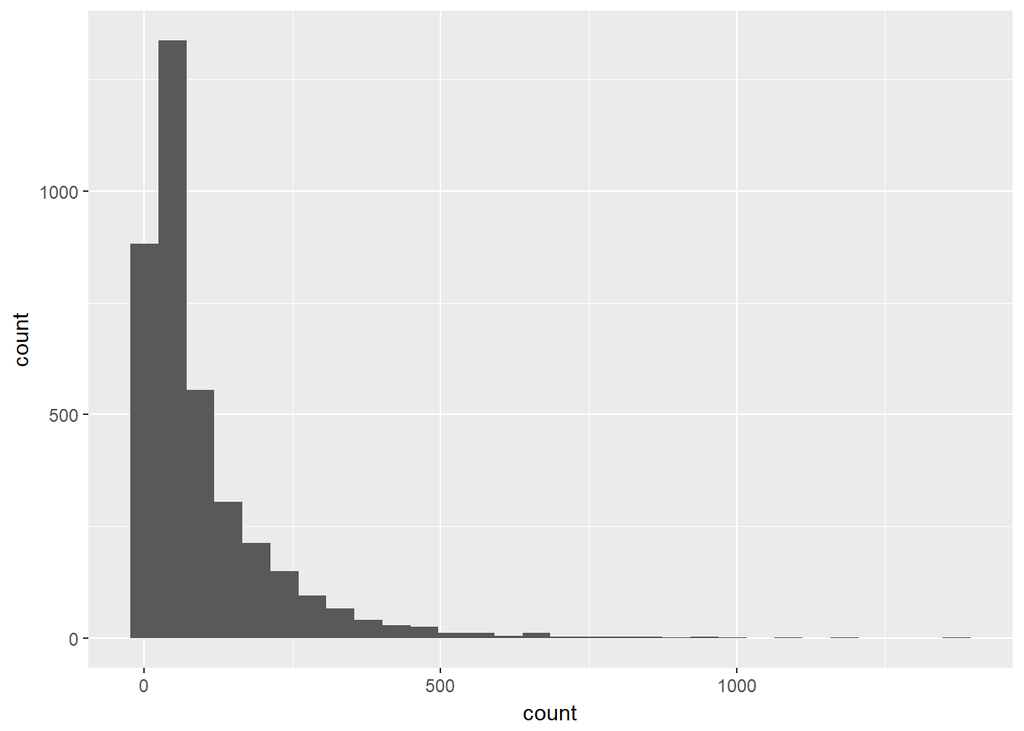

```r
ggplot(readings.count) + geom_histogram(aes(x = count))
```

2. What does the distribution of SpO2, hyperoxia duration, ventilation duration look like?

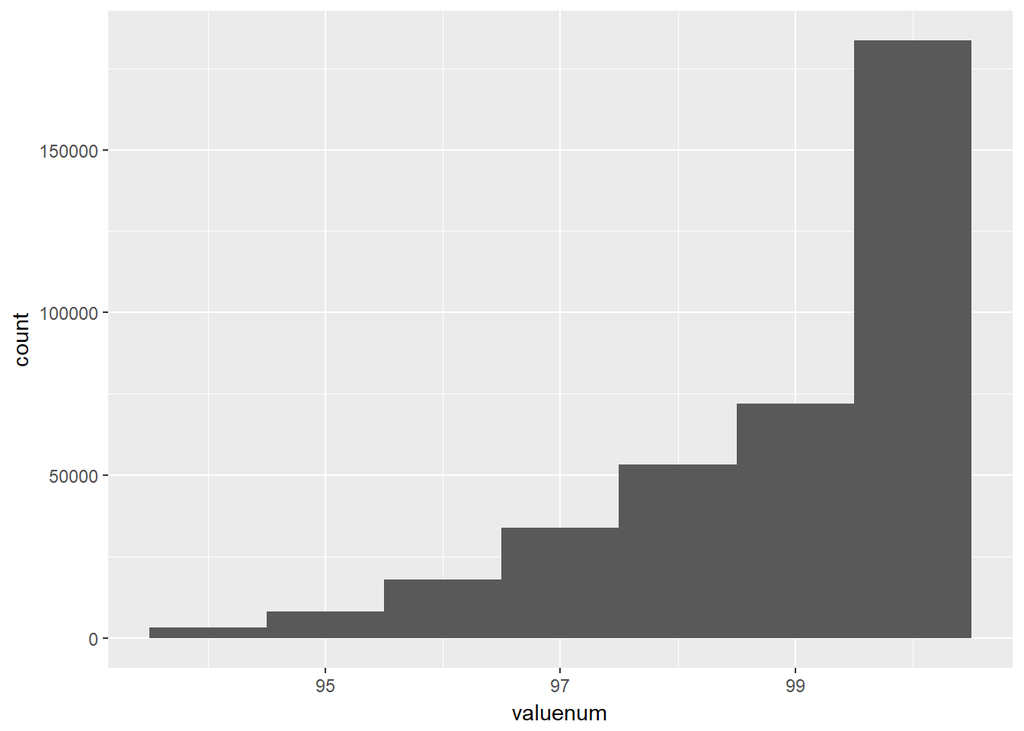

```r
ggplot(spo2.tidy.df) + geom_histogram(aes(x = valuenum), binwidth = 1)
```

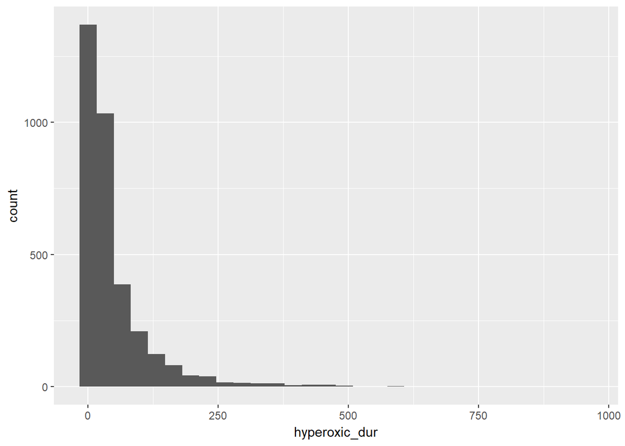

```r
ggplot(hs.eda.df) + geom_histogram(aes(x = hyperoxic_dur))
```

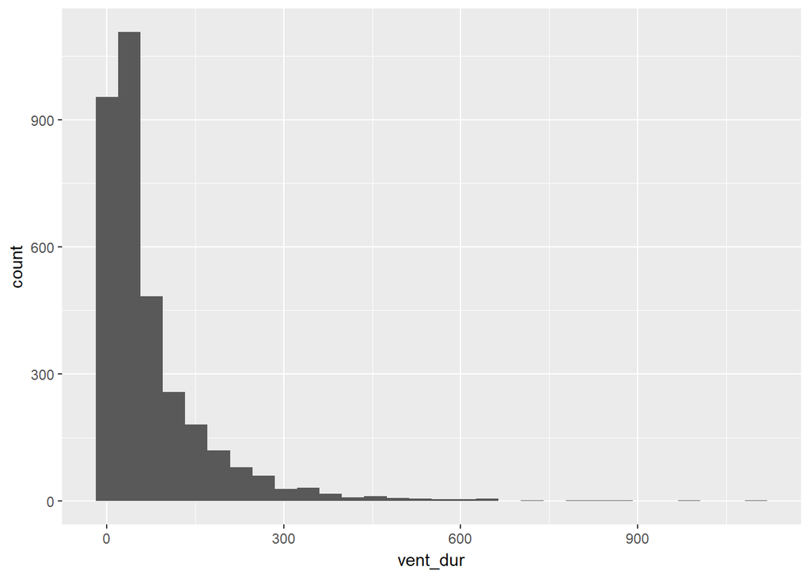

```r
ggplot(hs.eda.df) + geom_histogram(aes(x = vent_dur))
```

3. Are hyperoxic duration, vent duration, and LOS as related as we would expect?

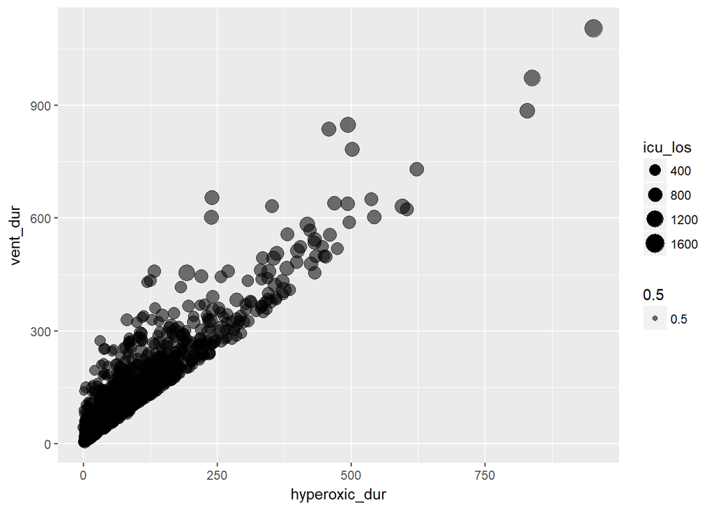

```r
ggplot(hs.eda.df) + geom_point(aes(x= hyperoxic_dur, y = vent_dur,
                                   size = icu_los, alpha = 0.5))
```

### Outcomes

#### Primary outcome 1: Hospital Expiration

Lets now see the proportion of patients in each group who achieved the ouctome.

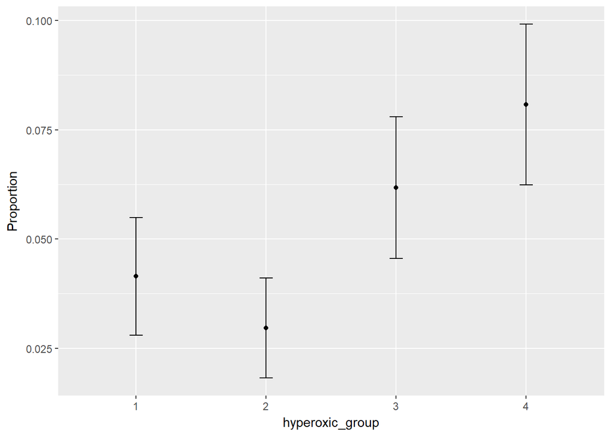

```r
plot_prop_by_level(hs.eda.df,"hyperoxic_group","hospital_expire")
```

Based on this, at least unadjusted, there appears to be a difference; lets look at crude odds ratio by group.

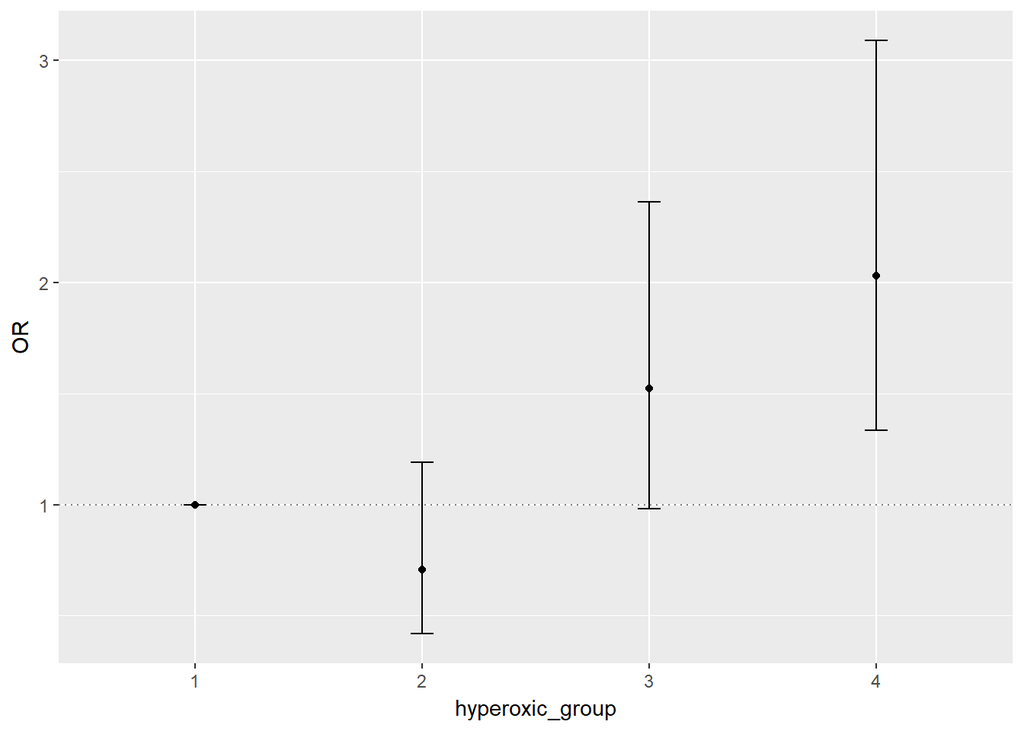

```r
plot_OR_by_level(hs.eda.df, "hyperoxic_group","hospital_expire")
```

There is a dip at hyperoxic_group 2, followed by increases in level 3 and 4. This is physiologically acceptable as some hyperoxia may be helpful, but at some point it may become detrimental.

We’ll examine this exposure/outcome relationship with model building after exploring the second primary outcome.

Other factor variables include gender, ethnicity, and care unit.

We can first examine the proportions of the outcome in the exposure groups as it changes when stratified for the factors.

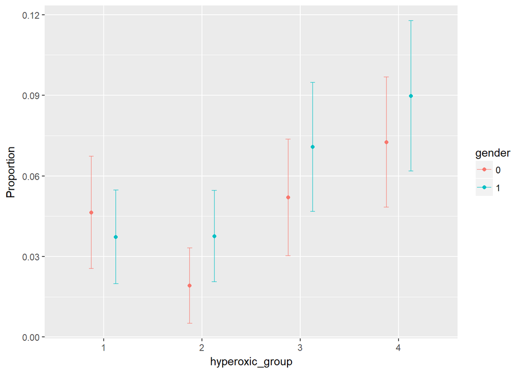

```r
plot_prop_by_level(hs.eda.df,"hyperoxic_group","hospital_expire",
                   factor.var2 = "gender")
```

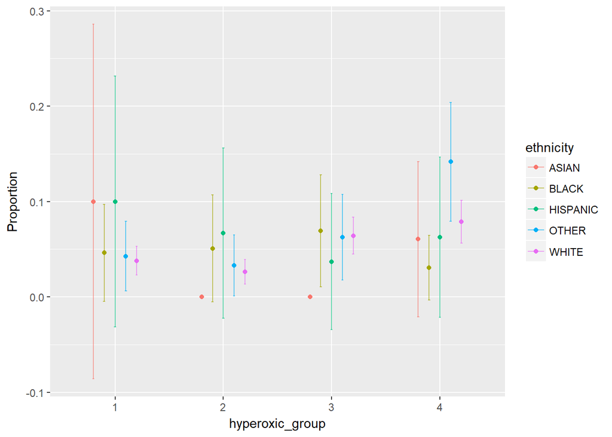

```r
plot_prop_by_level(hs.eda.df,"hyperoxic_group","hospital_expire",
                   factor.var2 = "ethnicity")
```

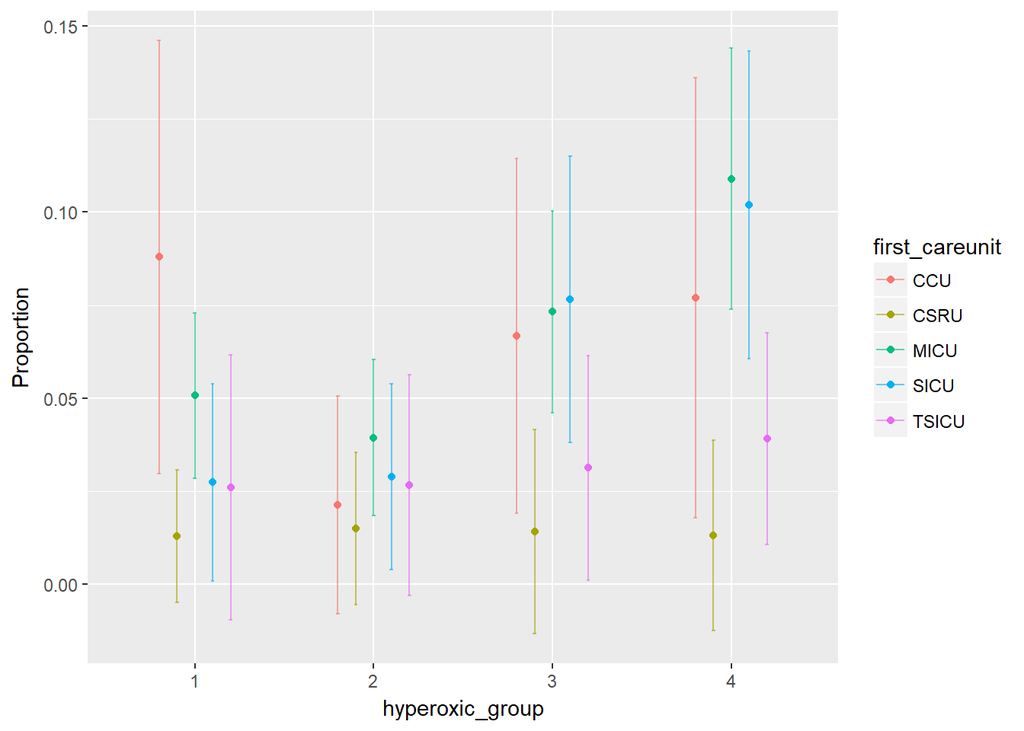

```r
plot_prop_by_level(hs.eda.df,"hyperoxic_group","hospital_expire",
                   factor.var2 = "first_careunit")
```

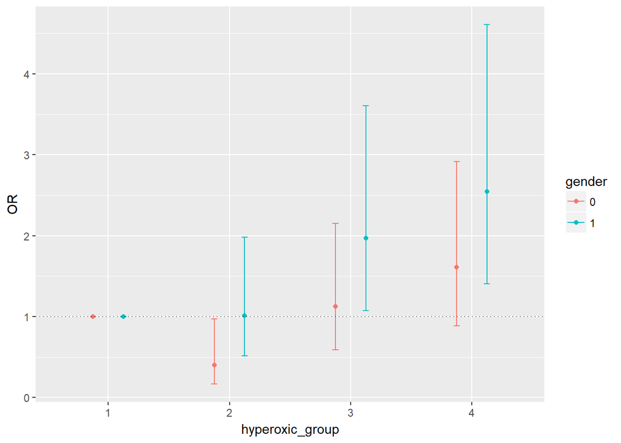

```r
plot_OR_by_level(hs.eda.df, "gender","hospital_expire",
                 factor.var2 = "hyperoxic_group")
```

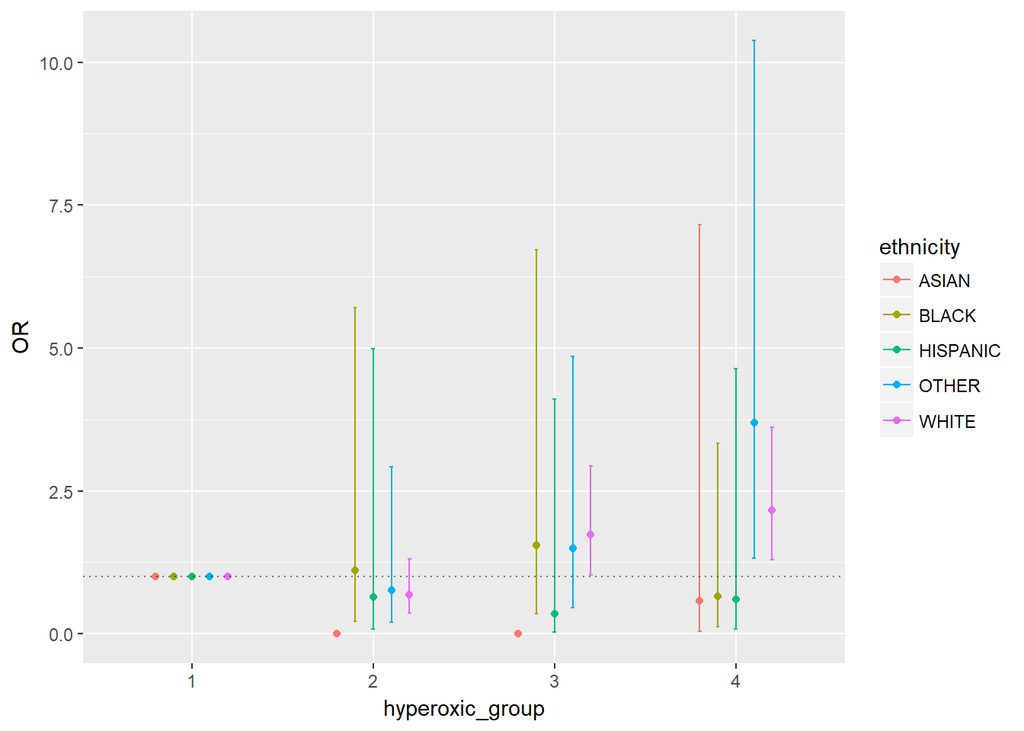

```r
plot_OR_by_level(hs.eda.df, "ethnicity","hospital_expire",
                 factor.var2 = "hyperoxic_group")
```

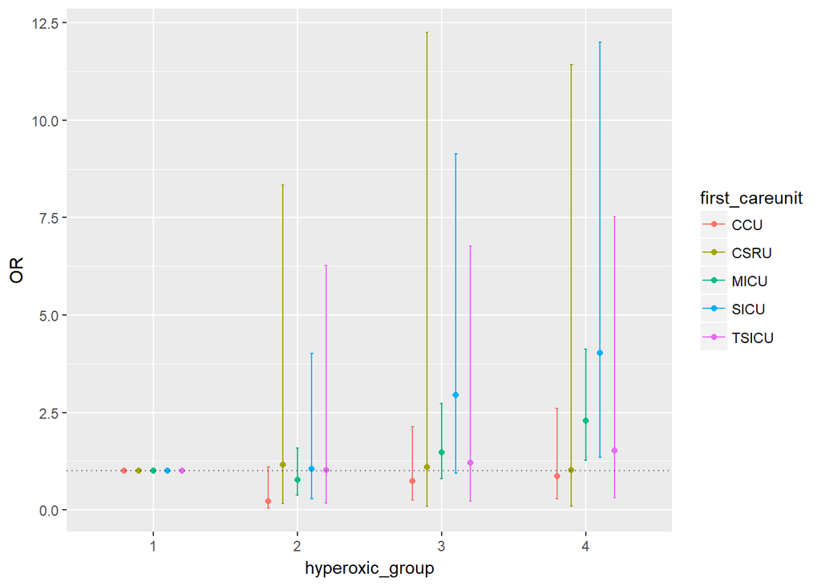

```r
plot_OR_by_level(hs.eda.df, "first_careunit","hospital_expire",
                 factor.var2 = "hyperoxic_group")
```

Rather interestingly, the point estimates are on different sides of the null by unit in some cases.

#### Primay Outcome 2: One-year Expire

Lets now see the proportion of patients in each group who achieved the ouctome.

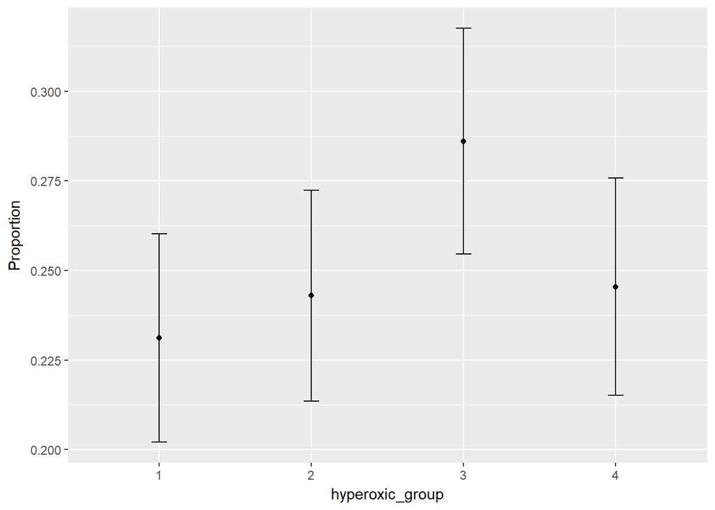

```r
plot_prop_by_level(hs.eda.df %>% filter(hospital_expire == 0),
                   "hyperoxic_group","oneyear_expire")
```

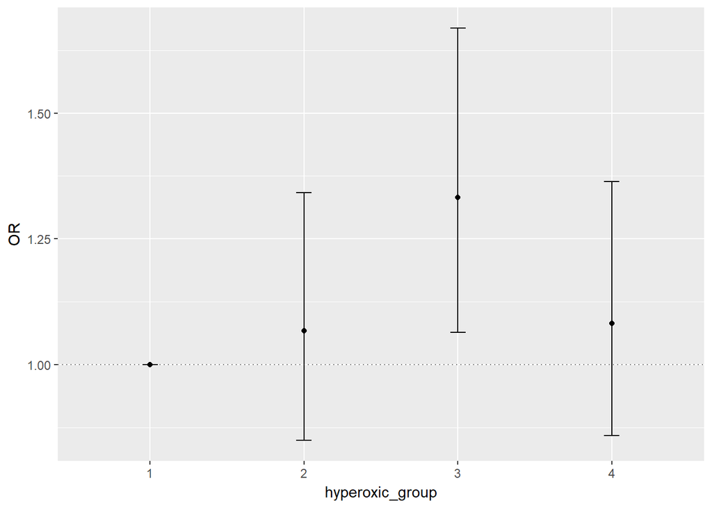

```r
plot_OR_by_level(hs.eda.df %>% filter(hospital_expire == 0),
                 "hyperoxic_group","oneyear_expire")
```